# MACHINE LEARNING ASSIGNMENT-5

RAHUL_R

2024-10-4

# QUESTION 1

## We will now try to predict per capita crime rate in the `Boston` data set.

### a. Try out some of the regression methods explored in this chapter, such as best subset selection, the lasso, ridge regression, and PCR. Present and discuss results for the approaches that you consider.

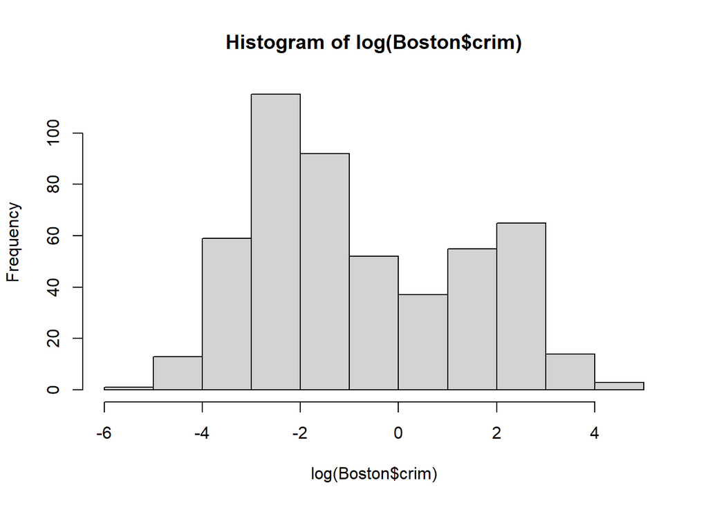

```r
set.seed(1)
train_boston <- sample(nrow(Boston), nrow(Boston) * 2 / 3)
training_data_boston <- Boston[train_boston, ]
testing_data_boston <- Boston[-train_boston, ]
crim_test <- testing_data_boston$crim
crim_train <-training_data_boston$crim
hist(log(Boston$crim))
```

```r
mse_list <- list()
```

```r
mm <- model.matrix(log(crim) ~ ., data = training_data_boston)
qa_lassofit <- cv.glmnet(mm, log(crim_train), alpha = 1)
p <- predict(qa_lassofit, model.matrix(log(crim) ~ ., data = testing_data_boston), s = qa_lassofit$lambda.min)
(mse_list$lasso <- mean((p - log(crim_test))^2))
```

```
## [1] 0.6536132
```

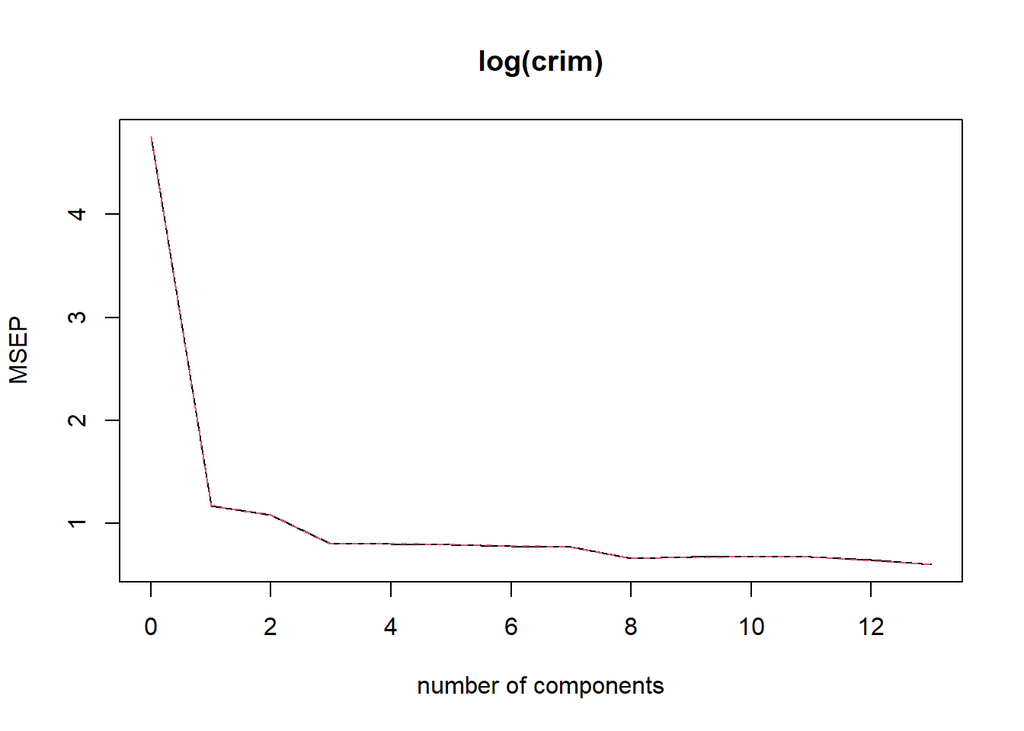

```r
fit4 <- pcr(log(crim) ~ ., data = training_data_boston, scale = TRUE, validation = "CV")
validationplot(fit4, val.type = "MSEP")
```

```r
p <- predict(fit4, testing_data_boston, ncomp = 13)
(mse_list$pcr <- mean((p - log(crim_test))^2))
```

```
## [1] 0.6779016
```

### b. Propose a model (or set of models) that seem to perform well on this dataset, and justify your answer. Make sure that you are evaluating model performance using validation set error, cross-validation, or some other reasonable alternative, as opposed to using training error.

We will try to fit models to `log(Boston$crim)` which is closer to a normal distribution.

```r
fit <- lm(log(crim) ~ ., data = training_data_boston)
mean((predict(fit, testing_data_boston) - log(crim_test))^2)
```

```
## [1] 0.6779016
```

```r
mm <- model.matrix(log(crim) ~ ., data = training_data_boston)
fit2 <- cv.glmnet(mm, log(crim_train), alpha = 0)
p <- predict(fit2, model.matrix(log(crim) ~ ., data = testing_data_boston), s = fit2$lambda.min)
(mse_list$ridge <- mean((p - log(crim_test))^2))
```

```
## [1] 0.665665
```

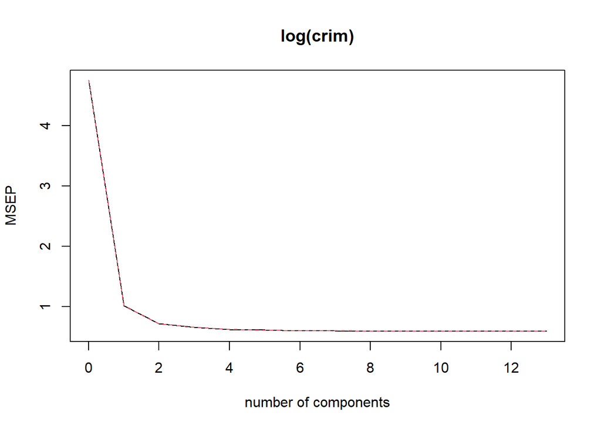

```r
fit5 <- plsr(log(crim) ~ ., data = training_data_boston, scale = TRUE, validation = "CV")
validationplot(fit5, val.type = "MSEP")
```

```r
p <- predict(fit5, testing_data_boston, ncomp = 6)
(mse_list$plsr <-mean((p - log(crim_test))^2))
```

```
## [1] 0.6911389
```

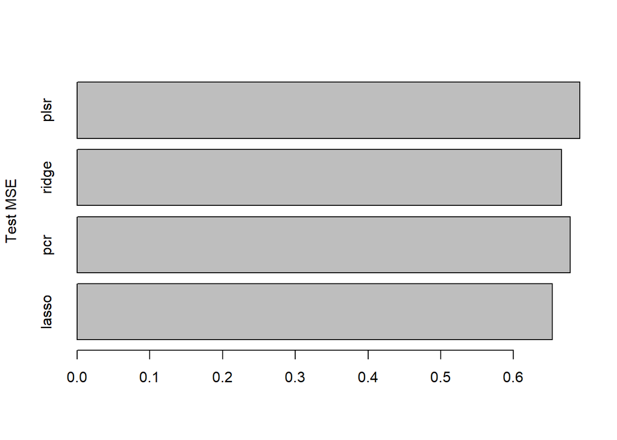

```r
barplot(unlist(mse_list), ylab = "Test MSE", horiz = TRUE)
```

```r
coef(qa_lassofit, s = fit2$lambda.min)
```

```
## 15 x 1 sparse Matrix of class "dgCMatrix"
##                        s1
## (Intercept) -4.7571188564
## (Intercept)  .
## zn          -0.0058859339
## indus        0.0183801862
## chas         .
## nox          4.1627107423
## rm           .
## age          0.0031650245
## dis          .
## rad          0.1293383590
## tax          .
## ptratio      .
## black       -0.0005571101
## lstat        0.0199240711
## medv         .
```

### c. Does your chosen model involve all of the features in the data set? Why or why not?

Not all features are included due to the lasso penalization.